# Nolan Ryan or Tommy John?

Matt Misterka

June 3, 2019

```r
setwd("C:\\Users\\Matt\\Documents\\Statistics\\Stat_Learning")
load("baseball_test.Rda")
load("baseball_train.Rda")
```

## View the Training Dataset

```r
DT::datatable(baseball.train,
              class = 'nowrap',
              options = list(autoWidth = TRUE,
                             columnDefs=list(list(width='50%', targets=0))))
```

|  | Opp | DR | IP | H | R | ER | BB | SO | HR | HBP | ERA | BF | GB | FB | LD | PU | Unk | SB | CS | PO | X2B | X3B | IBB | GDP | SF | ROE | Result | Name |
| --- | --- | --- | --- | --- | --- | --- | --- | --- | --- | --- | --- | --- | --- | --- | --- | --- | --- | --- | --- | --- | --- | --- | --- | --- | --- | --- | --- | --- |
| 1215 | CHC | 5 | 4.2 | 13 | 5 | 5 | 3 | 2 | 1 | 0 | 2.79 | 28 | 13 | 10 | 8 | 1 | 0 | 0 | 0 | 0 | 1 | 0 | 2 | 2 | 0 | 0 | L | Tommy |
| 164 | MIN | 3 | 9 | 6 | 4 | 4 | 6 | 12 | 1 | 0 | 2.92 | 37 | 5 | 8 | 1 | 1 | 6 | 1 | 3 | 0 | 2 | 0 | 0 | 0 | 0 | 1 | L | Nolan |
| 603 | ATL | 4 | 5 | 4 | 2 | 2 | 3 | 5 | 0 | 0 | 3.69 | 22 | 3 | 11 | 3 | 0 | 0 | 1 | 0 | 0 | 1 | 0 | 0 | 0 | 0 | 0 | L | Nolan |
| 223 | KCR | 3 | 10 | 4 | 2 | 2 | 4 | 15 | 0 | 0 | 3.02 | 38 | 7 | 8 | 1 | 3 | 4 | 1 | 0 | 0 | 1 | 0 | 0 | 0 | 0 | 0 | W | Nolan |
| 86 | LAD | 4 | 8 | 5 | 2 | 2 | 2 | 9 | 0 | 0 | 1.78 | 31 | 6 | 9 | 0 | 0 | 5 | 0 | 0 | 0 | 1 | 0 | 0 | 0 | 0 | 0 | L | Nolan |
| 751 | NYY | 4 | 9 | 4 | 3 | 2 | 3 | 6 | 2 | 0 | 2.88 | 34 | 8 | 17 | 3 | 6 | 0 | 0 | 0 | 0 | 0 | 0 | 0 | 1 | 0 | 1 | W | Nolan |
| 1509 | CLE | 4 | 2.1 | 6 | 7 | 5 | 3 | 0 | 0 | 1 | 4.17 | 17 | 4 | 3 | 1 | 0 | 6 | 0 | 0 | 0 | 2 | 0 | 1 | 1 | 0 | 1 | L | Tommy |
| 1248 | SDP | 4 | 9 | 6 | 1 | 1 | 2 | 3 | 0 | 0 | 3.24 | 35 | 18 | 6 | 0 | 1 | 6 | 0 | 0 | 0 | 0 | 0 | 1 | 0 | 0 | 0 | W | Tommy |
| 1157 | SFG | 4 | 6 | 4 | 3 | 1 | 2 | 2 | 0 | 0 | 2.57 | 23 | 5 | 10 | 3 | 1 | 4 | 0 | 0 | 0 | 1 | 0 | 0 | 1 | 0 | 0 | W | Tommy |
| 1367 | MIL | 4 | 2.2 | 6 | 6 | 6 | 0 | 2 | 0 | 0 | 3.36 | 14 | 5 | 1 | 0 | 0 | 6 | 0 | 0 | 0 | 1 | 1 | 0 | 0 | 1 | 0 | L | Tommy |

[output cut: 1536 more lines]

## Data Visualization

Let’s look at boxplots of strike outs, ground balls, and walks (BB).

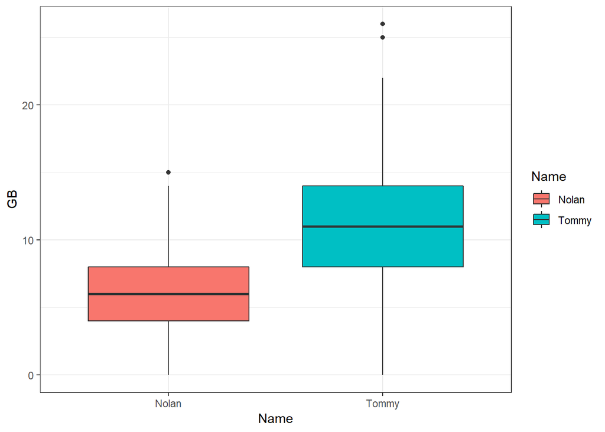

```r
ggplot(baseball.train, aes(x=Name, y=GB, fill=Name)) +
  geom_boxplot()+theme_bw()
```

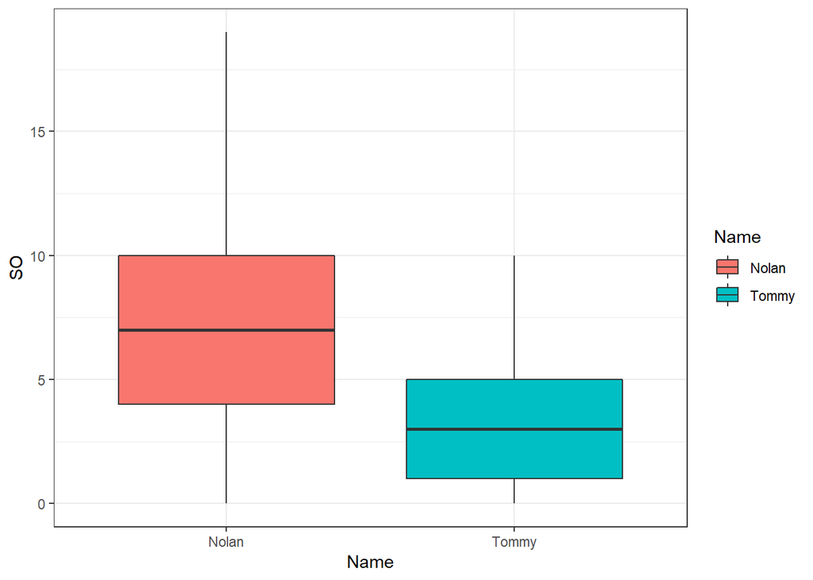

```r
ggplot(baseball.train, aes(x=Name, y=SO, fill=Name)) +
  geom_boxplot()+theme_bw()
```

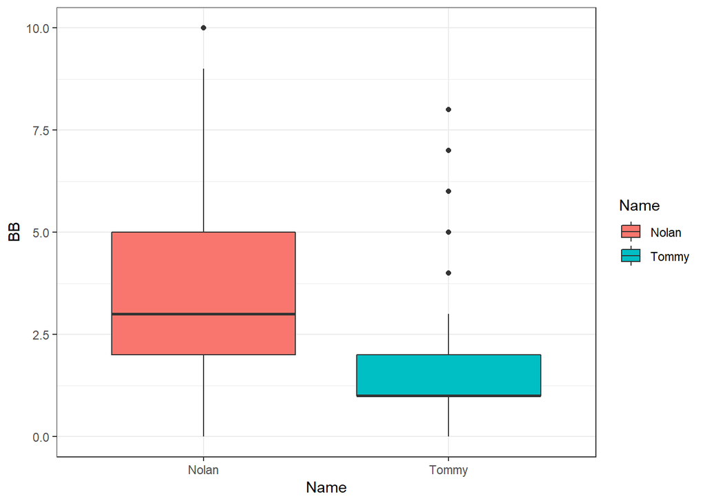

```r
ggplot(baseball.train, aes(x=Name, y=BB, fill=Name)) +
  geom_boxplot()+theme_bw()
```

## Logistic Model

Start off with a logistic model.

```r
ctrl <- trainControl(method="repeatedcv", number=5, repeats=10,
                     classProbs=TRUE, summaryFunction=twoClassSummary)

set.seed(21191)
logit <- train(Name ~.,
                      data=baseball.train,
                      method="glm",
                      metric="ROC",
                      preProcess=c("center", "scale"),
                      family=binomial(link="logit"),
                      trControl=ctrl)
```

## Forward Logistic Model

I removed the opponent variables in this model to speed up the computation.

```r
set.seed(21191)
forward_logit <- train(Name ~.-Opp,
                      data=baseball.train,
                      method="glmStepAIC",
                      direction="forward",
                      preProcess=c("center", "scale"),
                      family=binomial(link="logit"),
                      trace=FALSE,
                      trControl=ctrl)
forward_logit$finalModel
```

```
##
## Call:  NULL
##
## Coefficients:
## (Intercept)           SO           GB           BB           FB
##     -0.5859      -2.2773       2.0378      -1.0383      -1.3816
##         Unk           SB           LD            R           PU
##      0.7173      -0.5631       0.5051      -0.7279      -0.5429
##           H           PO           DR          ERA          IBB
##      0.7723      -0.1949       0.2043      -0.2158       0.1989
##
## Degrees of Freedom: 1545 Total (i.e. Null);  1531 Residual
## Null Deviance:       2142
## Residual Deviance: 672   AIC: 702
```

## Lasso Model

Let’s look at the lasso model. This model does implicit variable selection - setting some coefficients to 0.

```r
set.seed(21191)
lasso.mod <- train(Name ~.,
                         data=baseball.train,
                         method="glmnet",
                         metric="ROC",
                         preProcess=c("center", "scale"),
                         trControl=ctrl,
                         tuneGrid=expand.grid(alpha=1,
                                              lambda=10^seq(-2,0,0.01)))

kable(data.frame(Variable=c("Intercept",lasso.mod$coefnames),
           Coef=as.numeric(predict(lasso.mod$finalModel, type="coefficients",
                                   s=as.numeric(lasso.mod$bestTune[2]))))) %>%
  kable_styling(c("bordered"),full_width = FALSE,position = "left")
```

| Variable | Coef |
| --- | --- |
| Intercept | -0.3208870 |
| OppBAL | 0.1105138 |
| OppBOS | 0.0000000 |
| OppCAL | 0.1469484 |
| OppCHC | -0.0947144 |
| OppCHW | 0.0000000 |
| OppCIN | -0.0614289 |
| OppCLE | 0.0713630 |
| OppDET | 0.1279084 |
| OppHOU | 0.0000000 |
| OppKCA | 0.0811649 |
| OppKCR | 0.0000000 |
| OppLAA | 0.0000000 |
| OppLAD | -0.3519144 |
| OppMIL | 0.0000000 |
| OppMIN | 0.0362213 |
| OppMON | -0.1458874 |
| OppNYM | 0.0000000 |
| OppNYY | 0.0000000 |
| OppOAK | 0.1060652 |
| OppPHI | -0.0921314 |
| OppPIT | -0.1038198 |
| OppSDP | -0.1364058 |
| OppSEA | 0.0000000 |
| OppSEP | 0.0000000 |
| OppSFG | -0.0408885 |
| OppSTL | -0.0494123 |
| OppTEX | 0.0000000 |
| OppTOR | 0.0000000 |
| OppWSA | 0.2515334 |
| DR | 0.0000000 |
| IP | 0.0000000 |
| H | 0.3922035 |
| R | -0.2209528 |
| ER | 0.0000000 |
| BB | -0.8687787 |
| SO | -1.5791283 |
| HR | 0.0000000 |
| HBP | 0.0000000 |
| ERA | -0.0364412 |
| BF | 0.0000000 |
| GB | 1.4969367 |
| FB | -0.6865643 |
| LD | 0.0070053 |
| PU | -0.3398111 |
| Unk | 0.2909305 |
| SB | -0.2894411 |
| CS | 0.0000000 |
| PO | -0.0263786 |
| X2B | 0.0000000 |
| X3B | 0.0000000 |
| IBB | 0.0284480 |
| GDP | 0.0000000 |
| SF | 0.0000000 |
| ROE | 0.0000000 |
| ResultW | 0.0000000 |

## Elastic Model

This model finds a balance between ridge and lasso models. Investigate the coefficients.

```r
set.seed(21191)
elastic.mod <- train(Name ~.,
                         data=baseball.train,
                         method="glmnet",
                         metric="ROC",
                         preProcess=c("center", "scale"),
                         trControl=ctrl,
                         tuneGrid=expand.grid(alpha=seq(0,1,0.1),
                                              lambda=10^seq(-2,0,0.01)))

kable(data.frame(Variable=c("Intercept",elastic.mod$coefnames),
           Coef=as.numeric(predict(elastic.mod$finalModel, type="coefficients",
                                   s=as.numeric(elastic.mod$bestTune[2]))))) %>%
  kable_styling(c("bordered"),full_width = FALSE,position = "left")
```

| Variable | Coef |
| --- | --- |
| Intercept | -0.2673120 |
| OppBAL | 0.1965888 |
| OppBOS | 0.0833879 |
| OppCAL | 0.2489383 |
| OppCHC | -0.1280430 |
| OppCHW | -0.0556663 |
| OppCIN | -0.1029527 |
| OppCLE | 0.1712717 |
| OppDET | 0.2360914 |
| OppHOU | 0.0555533 |
| OppKCA | 0.1926901 |
| OppKCR | 0.0437148 |
| OppLAA | 0.0790201 |
| OppLAD | -0.4067321 |
| OppMIL | 0.0758785 |
| OppMIN | 0.1496479 |
| OppMON | -0.1731363 |
| OppNYM | -0.0159089 |
| OppNYY | 0.0793489 |
| OppOAK | 0.2223586 |
| OppPHI | -0.1318333 |
| OppPIT | -0.1498254 |
| OppSDP | -0.1551157 |
| OppSEA | 0.0558354 |
| OppSEP | 0.0207793 |
| OppSFG | -0.0878814 |
| OppSTL | -0.1029952 |
| OppTEX | 0.0019301 |
| OppTOR | 0.0934764 |
| OppWSA | 0.3338432 |
| DR | 0.0667944 |
| IP | -0.0494596 |
| H | 0.4357988 |
| R | -0.2261503 |
| ER | -0.1006617 |
| BB | -0.8240784 |
| SO | -1.2875154 |
| HR | -0.0008173 |
| HBP | -0.0920938 |
| ERA | -0.1129718 |
| BF | -0.0841588 |
| GB | 1.2654914 |
| FB | -0.6691734 |
| LD | 0.2131488 |
| PU | -0.4562659 |
| Unk | 0.4404366 |
| SB | -0.3344358 |
| CS | 0.0055955 |
| PO | -0.0946002 |
| X2B | 0.0000000 |
| X3B | 0.0036886 |
| IBB | 0.1143809 |
| GDP | 0.0877615 |
| SF | -0.0548286 |
| ROE | 0.0000000 |
| ResultW | 0.0583913 |

## Dummy Variables and LDA

I create five dummy variables for opponents. Variables were chosen by looking at coefficients of the elastic model. I also took into consideration the teams that each player played on as well as divisional opponents. I selected a subset of numeric variables. Train LDA model - assumes a common covariance structure. Examine the coviance structure.

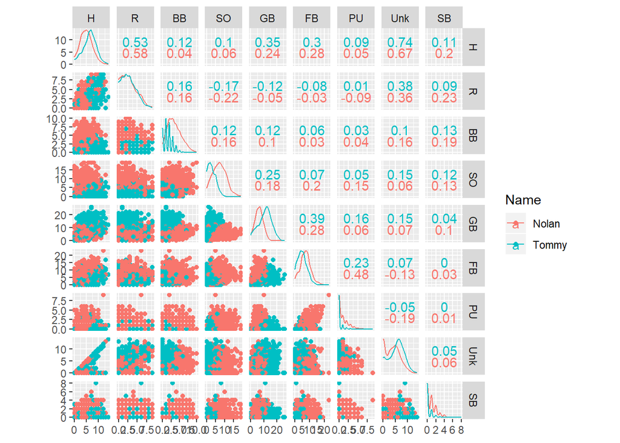

```r
baseball.train$MON<-ifelse(baseball.train$Opp=="MON",1,0)
baseball.train$CAL<-ifelse(baseball.train$Opp=="CAL",1,0)
baseball.train$LAD<-ifelse(baseball.train$Opp=="LAD",1,0)
baseball.train$OAK<-ifelse(baseball.train$Opp=="OAK",1,0)
baseball.train$WSA<-ifelse(baseball.train$Opp=="WSA",1,0)

cols <- c("MON","CAL","LAD","OAK","WSA")
baseball.train[cols] <- lapply(baseball.train[cols],as.factor)

ggscatmat(baseball.train, c(4:5,7:8,13:14,16:18), color="Name",alpha = 1)
```

```r
set.seed(21191)
mod.lda <- train(Name ~ H+R+BB+SO+GB+FB+PU+Unk+SB+MON+CAL+LAD+OAK+WSA,
                         data=baseball.train,
                      method="lda",
                      metric="ROC",
                      output=FALSE,
                      trControl=ctrl)
```

## Random Forest

A random forest with selected oppenents and numeric variables present in forward, lasso, and elastic models simultaneously. Let’s look at a variable importance plot.

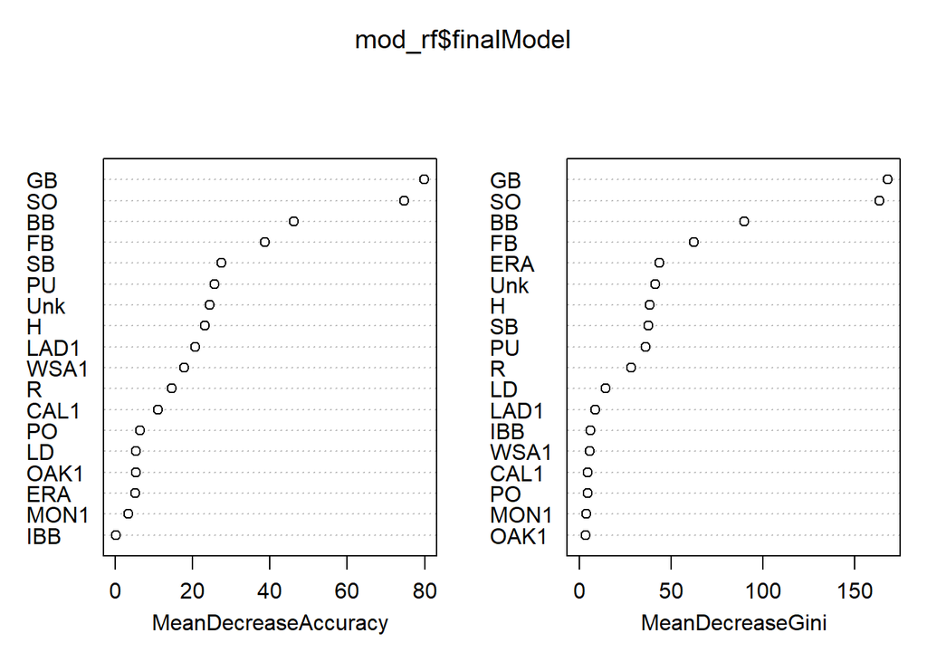

```r
set.seed(21191)
mod_rf <- train(Name ~ H+R+ERA+BB+SO+GB+FB+LD+PO+PU+Unk+SB+IBB+MON+CAL+LAD+OAK+WSA,
                data=baseball.train,
                method="rf",
                metric="ROC",
                preProcess=c("center", "scale"),
                trControl=ctrl,
                tuneGrid=expand.grid(mtry=c(4,5)),
                importance=TRUE)

varImpPlot(mod_rf$finalModel)
```

## Boosted Tree

```r
set.seed(21191)
mod.boosttree <- train(Name ~ H+R+ERA+BB+SO+GB+FB+LD+PO+PU+Unk+SB+IBB+MON+CAL+LAD+OAK+WSA,
                       data=baseball.train,
                       method="gbm",
                       metric="ROC",
                       preProcess=c("center", "scale"),
                       trControl=ctrl,
                       distribution="bernoulli",
                       verbose=FALSE,
                       tuneGrid=expand.grid(n.trees=c(1000),
                                            interaction.depth=1:2,
                                            shrinkage=c(0.1,0.01,0.001),
                                            n.minobsinnode=c(10,20) ) )
```

## KNN Model

```r
set.seed(21191)
mod.knn <- train(Name ~ H+R+ERA+BB+SO+GB+FB+LD+PO+PU+Unk+SB+IBB+MON+CAL+LAD+OAK+WSA,
                     data=baseball.train,
                     method="knn",
                     preProcess=c("center", "scale"),
                     metric="ROC",
                     trControl=ctrl,
                     tuneGrid=expand.grid(k=seq(1,49,2)))
```

## KNN Model 2

```r
set.seed(21191)
mod.knn7 <- train(Name ~ H+R+ERA+BB+SO+GB+FB+LD+PO+PU+Unk+SB+IBB,
                     data=baseball.train,
                     method="knn",
                     preProcess=c("center", "scale"),
                     metric="ROC",
                     trControl=ctrl,
                     tuneGrid=expand.grid(k=7))

pred.knn7 <- predict(mod.knn7, newdata=baseball.test)

confusionMatrix(pred.knn7, baseball.test$Name)
```

```
## Confusion Matrix and Statistics
##
##           Reference
## Prediction Nolan Tommy
##      Nolan     9     3
##      Tommy     2     6
##
##                Accuracy : 0.75
##                  95% CI : (0.509, 0.9134)
##     No Information Rate : 0.55
##     P-Value [Acc > NIR] : 0.05533
##
##                   Kappa : 0.4898
##  Mcnemar's Test P-Value : 1.00000
##
##             Sensitivity : 0.8182
##             Specificity : 0.6667
##          Pos Pred Value : 0.7500
##          Neg Pred Value : 0.7500
##              Prevalence : 0.5500
##          Detection Rate : 0.4500
##    Detection Prevalence : 0.6000
##       Balanced Accuracy : 0.7424
##
##        'Positive' Class : Nolan
##
```

## Partial Least Squares

```r
set.seed(21191)
mod.pls <- train(Name ~ H+R+ERA+BB+SO+GB+FB+LD+PO+PU+Unk+SB+IBB+MON+CAL+LAD+OAK+WSA,
                 data=baseball.train,
                 method="pls",
                 preProcess=c("center", "scale"),
                 metric="ROC",
                 trControl=ctrl,
                 tuneGrid=expand.grid(ncomp=1:18))
```

## Generalized Additive Model

```r
set.seed(21191)
mod.gamCubic <- train(Name ~ H+R+ERA+BB+SO+GB+FB+LD+PO+PU+Unk+SB+IBB+MON+CAL+LAD+OAK+WSA,
                      data=baseball.train,
                      method="gam",
                      preProcess=c("center", "scale"),
                      metric="ROC",
                      trControl=ctrl,
                      tune.length=20)
```

## Neural Net

```r
set.seed(21191)
mod.nnet <- train(Name ~ H+R+ERA+BB+SO+GB+FB+LD+PO+PU+Unk+SB+IBB,
                  data=baseball.train,
                  method="nnet",
                  preProcess=c("center", "scale"),
                  metric="ROC",
                  trControl=ctrl,
                  tuneGrid=expand.grid(size=seq(1,7,1),
                                       decay=seq(0,0.1,0.005) ),
                  linout=0,
                  trace=FALSE)
```

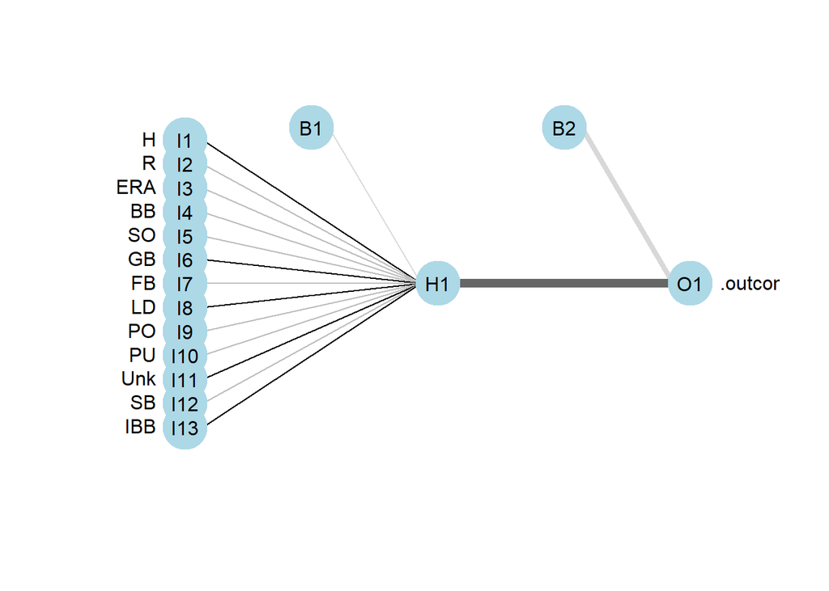

```r
plotnet(mod.nnet$finalModel, alpha=0.6)
```

## Support Vector Machine

```r
set.seed(21191)
mod.svm.lin <- train(Name ~ H+R+ERA+BB+SO+GB+FB+LD+PO+PU+Unk+SB+IBB+MON+CAL+LAD+OAK+WSA,
                     data=baseball.train,
                     method="svmLinear",
                     metric="ROC",
                     trControl=ctrl,
                     preProcess = c("center", "scale"),
                     tuneGrid=expand.grid(C=c(seq(0.1,1,0.1),1.5,2,3,4)))
```

## Comparison of Models

It looks like the elastic model does well in terms of ROC.

```r
out <- resamples(list(Logistic=logit, StepLogit=forward_logit,
                      Lasso=lasso.mod, Elastic=elastic.mod,
                      LDA=mod.lda, RandomForest=mod_rf,
                      Boosted=mod.boosttree, KNN=mod.knn,
                      PLS=mod.pls,GAM=mod.gamCubic, NNET=mod.nnet,
                      SVM=mod.svm.lin))
summary(out)$statistics$ROC %>%
kable() %>% kable_styling(full_width=FALSE)
```

|  | Min. | 1st Qu. | Median | Mean | 3rd Qu. | Max. | NA’s |
| --- | --- | --- | --- | --- | --- | --- | --- |
| Logistic | 0.9586164 | 0.9716781 | 0.9756946 | 0.9750286 | 0.9796646 | 0.9901048 | 0 |
| StepLogit | 0.9419706 | 0.9632075 | 0.9675262 | 0.9673915 | 0.9727044 | 0.9825577 | 0 |
| Lasso | 0.9565199 | 0.9701048 | 0.9747500 | 0.9741430 | 0.9788574 | 0.9872117 | 0 |
| Elastic | 0.9603354 | 0.9733229 | 0.9767505 | 0.9767082 | 0.9823166 | 0.9896855 | 0 |
| LDA | 0.9514885 | 0.9703197 | 0.9751153 | 0.9734875 | 0.9785010 | 0.9854927 | 0 |
| RandomForest | 0.9294549 | 0.9591929 | 0.9624896 | 0.9629822 | 0.9697013 | 0.9800629 | 0 |
| Boosted | 0.9421384 | 0.9667505 | 0.9731656 | 0.9717552 | 0.9775472 | 0.9865409 | 0 |
| KNN | 0.9270650 | 0.9535744 | 0.9599790 | 0.9586416 | 0.9640503 | 0.9774843 | 0 |
| PLS | 0.9500210 | 0.9696541 | 0.9751153 | 0.9742318 | 0.9792453 | 0.9880922 | 0 |
| GAM | 0.9431447 | 0.9631447 | 0.9697484 | 0.9683535 | 0.9738050 | 0.9822642 | 0 |
| NNET | 0.9441929 | 0.9646570 | 0.9694047 | 0.9683315 | 0.9735325 | 0.9838574 | 0 |
| SVM | 0.9536268 | 0.9689937 | 0.9745667 | 0.9738032 | 0.9785430 | 0.9876310 | 0 |

# Predict

Looks like the knn model does well. Correctly classifying 17 of 20.

```r
baseball.test$MON<-ifelse(baseball.test$Opp=="MON",1,0)
baseball.test$CAL<-ifelse(baseball.test$Opp=="CAL",1,0)
baseball.test$LAD<-ifelse(baseball.test$Opp=="LAD",1,0)
baseball.test$OAK<-ifelse(baseball.test$Opp=="OAK",1,0)
baseball.test$WSA<-ifelse(baseball.test$Opp=="WSA",1,0)

cols <- c("MON","CAL","LAD","OAK","WSA")
baseball.test[cols] <- lapply(baseball.test[cols],as.factor)

our.pred <- data.frame(Logistic=predict(logit, newdata=baseball.test),
                       StepLogistic=predict(forward_logit, newdata=baseball.test),
                       Lasso=predict(lasso.mod, newdata=baseball.test),
                       Elastic=predict(elastic.mod, newdata=baseball.test),
                       LDA=predict(mod.lda, newdata=baseball.test),
                       RF=predict(mod_rf, newdata=baseball.test),
                       Boosted=predict(mod.boosttree, newdata=baseball.test),
                       KNN=predict(mod.knn, newdata=baseball.test),
                       PLS=predict(mod.pls, newdata=baseball.test),
                       GAM=predict(mod.gamCubic, newdata=baseball.test),
                       NeuralNet=predict(mod.nnet, newdata=baseball.test),
                       SVM=predict(mod.svm.lin, newdata=baseball.test))

true<-baseball.test$Name

out <- data.frame(t(apply(our.pred, 2, function(x) { tmp<-confusionMatrix(as.factor(x), reference=true); c(tmp$overall[1], tmp$byClass[1:2])  } ) ) )

names(out) <- c("Accuracy", "Sensitivity", "Specificity")
out %>% kable() %>%
  kable_styling(full_width=FALSE,
                bootstrap_options = "bordered")
```

|  | Accuracy | Sensitivity | Specificity |
| --- | --- | --- | --- |
| Logistic | 0.85 | 1.0000000 | 0.6666667 |
| StepLogistic | 0.75 | 0.9090909 | 0.5555556 |
| Lasso | 0.80 | 0.9090909 | 0.6666667 |
| Elastic | 0.80 | 0.8181818 | 0.7777778 |
| LDA | 0.80 | 0.9090909 | 0.6666667 |
| RF | 0.75 | 0.8181818 | 0.6666667 |
| Boosted | 0.80 | 1.0000000 | 0.5555556 |
| KNN | 0.85 | 0.8181818 | 0.8888889 |
| PLS | 0.80 | 0.9090909 | 0.6666667 |
| GAM | 0.75 | 0.9090909 | 0.5555556 |
| NeuralNet | 0.75 | 0.9090909 | 0.5555556 |
| SVM | 0.80 | 0.9090909 | 0.6666667 |

```r
preds<-data.frame(true,our.pred[8])
names(preds)<-c("truth","prediction")
kable(preds)%>%
  kable_styling(c("bordered"),full_width = FALSE)
```

| truth | prediction |
| --- | --- |
| Nolan | Nolan |
| Tommy | Tommy |
| Tommy | Tommy |
| Nolan | Nolan |
| Nolan | Tommy |
| Nolan | Nolan |
| Nolan | Nolan |
| Tommy | Tommy |
| Nolan | Nolan |
| Nolan | Nolan |
| Nolan | Nolan |
| Nolan | Tommy |
| Tommy | Tommy |
| Tommy | Nolan |
| Tommy | Tommy |
| Tommy | Tommy |
| Tommy | Tommy |
| Nolan | Nolan |
| Tommy | Tommy |
| Nolan | Nolan |